# IODS course project

This is explored further by making a linear regression model. I will choose the exam points as the target variable and surface learning and attitude as the explanative variables. Due to instruction limitations, I will add in strategic learning to have three.

```r
# create a regression model with multiple explanatory variables
my_model2 <- lm(points ~ attitude + surf +stra, data = learning2014)

# print out a summary of the model

summary(my_model2)
```

```
##
## Call:
## lm(formula = points ~ attitude + surf + stra, data = learning2014)
##
## Residuals:
##      Min       1Q   Median       3Q      Max
## -17.1550  -3.4346   0.5156   3.6401  10.8952
##
## Coefficients:
##             Estimate Std. Error t value Pr(>|t|)
## (Intercept)  11.0171     3.6837   2.991  0.00322 **
## attitude      3.3952     0.5741   5.913 1.93e-08 ***
## surf         -0.5861     0.8014  -0.731  0.46563
## stra          0.8531     0.5416   1.575  0.11716
## ---
## Signif. codes:  0 '***' 0.001 '**' 0.01 '*' 0.05 '.' 0.1 ' ' 1
##
## Residual standard error: 5.296 on 162 degrees of freedom
## Multiple R-squared:  0.2074, Adjusted R-squared:  0.1927
## F-statistic: 14.13 on 3 and 162 DF,  p-value: 3.156e-08
```

So, here we have the relevant parts summarized as far it pertains to the model:

**Residuals** represent the differences between the observed values and the values predicted by the model. The spread and distribution of residuals give insights into how well the model fits the data. We have a minimum of -17 and maximum of almost 11. However, this is hardly surprising as we saw relatively wide variation in exam scores for example in the surface learning category. The summary statistics (Min, 1Q, Median, 3Q, Max) describe the spread and central tendency of these residuals.

The “Pr(>|t|)” column provides p-values for the hypothesis test that each coefficient is equal to zero. In this case, attitude is statistically significant (p-value = 1.93e-08), while surf and stra are not.

**Residual Standard Error** is an estimate of the standard deviation of the residuals. In this model, it’s 5.296. It gives you an idea of the average magnitude of the errors in the model.

**R-squared** measures the proportion of variance in the dependent variable that is explained by the independent variables. In this model, R-squared is 0.2074, indicating that approximately 20.74% of the variance in points is explained by the attitude, surf, and stra variables. The adjusted R-squared accounts for the number of predictors in the model and is 0.1927.

The **F-statistic** tests the overall significance of the model. The F-statistic is 14.13 with a very low p-value (3.156e-08), suggesting that the model as a whole is statistically significant.The variable “attitude” is statistically significant and has a positive association with points. The variables “surf” and “stra” are not statistically significant, and their coefficients are not different from zero at conventional significance levels.

However, as we were ordered to look for statistically important criteria, I guess I will repeat the process with less inspiring and interesting variables

```r
# create a regression model with multiple explanatory variables
my_model3 <- lm(points ~ attitude + deep +stra, data = learning2014)

# print out a summary of the model

summary(my_model3)
```

```
##
## Call:
## lm(formula = points ~ attitude + deep + stra, data = learning2014)
##
## Residuals:
##      Min       1Q   Median       3Q      Max
## -17.5239  -3.4276   0.5474   3.8220  11.5112
##
## Coefficients:
##             Estimate Std. Error t value Pr(>|t|)
## (Intercept)  11.3915     3.4077   3.343  0.00103 **
## attitude      3.5254     0.5683   6.203 4.44e-09 ***
## deep         -0.7492     0.7507  -0.998  0.31974
## stra          0.9621     0.5367   1.793  0.07489 .
## ---
## Signif. codes:  0 '***' 0.001 '**' 0.01 '*' 0.05 '.' 0.1 ' ' 1
##
## Residual standard error: 5.289 on 162 degrees of freedom
## Multiple R-squared:  0.2097, Adjusted R-squared:  0.195
## F-statistic: 14.33 on 3 and 162 DF,  p-value: 2.521e-08
```

Now if we look at coefficients, for deep coefficient is -0.7492, but it is not statistically significant (p-value = 0.31974). For strategic learning, the coefficient is 0.9621, but it is marginally significant (p-value = 0.07489).

So basically by including the least significant predictor, deep, we likely just simplified the model slightly to appear a tiny bit more predictive.

Having all explanatory variables be statistically significant appears to be a foregone conclusion using this dataset.

Unless…

```r
# create a regression model with multiple explanatory variables
my_model4 <- lm(surf ~ attitude  + deep +stra, data = learning2014)

# print out a summary of the model

summary(my_model4)
```

```
##
## Call:
## lm(formula = surf ~ attitude + deep + stra, data = learning2014)
##
## Residuals:
##      Min       1Q   Median       3Q      Max
## -1.58598 -0.29940  0.01126  0.30875  1.28589
##
## Coefficients:
##             Estimate Std. Error t value Pr(>|t|)
## (Intercept)  4.40279    0.31894  13.805  < 2e-16 ***
## attitude    -0.09792    0.05319  -1.841   0.0675 .
## deep        -0.28338    0.07026  -4.034 8.44e-05 ***
## stra        -0.08494    0.05023  -1.691   0.0927 .
## ---
## Signif. codes:  0 '***' 0.001 '**' 0.01 '*' 0.05 '.' 0.1 ' ' 1
##
## Residual standard error: 0.495 on 162 degrees of freedom
## Multiple R-squared:  0.1398, Adjusted R-squared:  0.1239
## F-statistic: 8.778 on 3 and 162 DF,  p-value: 1.987e-05
```

Well, there we have it.

attitude: The coefficient is -0.09792, and it is marginally significant (p-value = 0.0675). deep: The coefficient is -0.28338, and it is statistically significant (p-value = 8.44e-05). stra: The coefficient is -0.08494, and it is marginally significant (p-value = 0.0927).

R-squared is 0.1398, indicating that the variables included in the model explain about 13.98% and F-statistic is 8.778 with a very low p-value (1.987e-05), suggesting that the model as a whole is statistically significant.

As this is a fools errand, I will return to **model2** as it was the one I found most interesting.

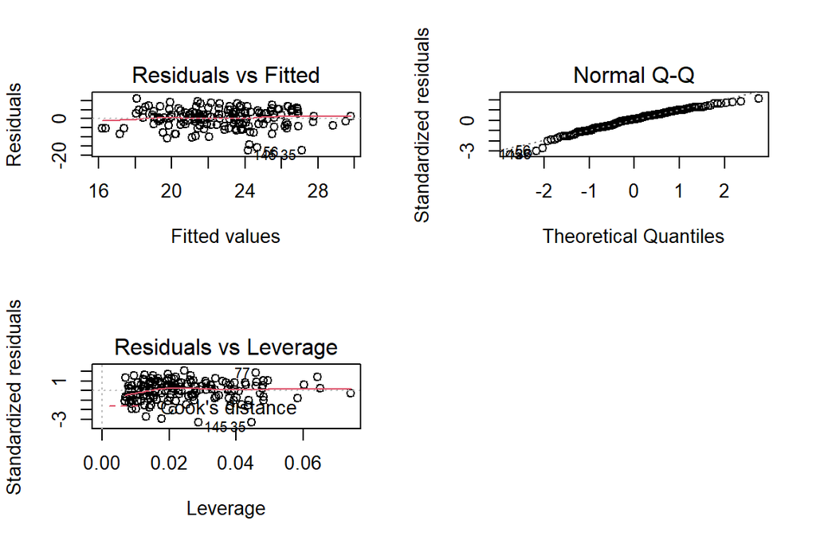

```r
# draw diagnostic plots using the plot() function. Choose the plots 1, 2 and 5

par(mfrow = c(2,2))
plot(my_model2, which = c(1,2,5))
```

In a linear regression analysis, the **residuals vs. fitted** plot is a diagnostic tool that helps assess the goodness of fit of the model. The x-axis represents the fitted (predicted) values from the regression model. These are the values that model predicts based on the independent variables.The y-axis represents the residuals, which are the differences between the observed values and the predicted values from the model. Mathematically, a residual is calculated as the observed value minus the predicted value. Each point on the plot corresponds to a data point in the dataset. It shows the relationship between the fitted values and the residuals.

Ideally, in a well-fitted model, one would not observe a clear pattern in the residuals vs. fitted plot. The residuals should be scattered randomly around zero, indicating that the model captures the underlying patterns in the data. As you can see, this is not exactly the case. However, as there is a huge element of human performance in the data, it would take someone with an interest and experience in humanities to really assess whether this is normal in this kind of dataset. Points far from the main cluster may represent outliers or influential observations, possibly poor exam performance due to badly slept night or just occasional divergence from studying habits, who knows. However, there is a slight “funnel” like spread in the points, suggesting possible heteroscedasticity, suggesting that the variance of the residuals might not be constant across all levels of the independent variable.

**A normal quantile-quantile (Q-Q)** plot is a graphical tool used to assess whether a given dataset follows a normal distribution. The Q-Q plot compares the quantiles of the observed data against the quantiles of a theoretical normal distribution. Each point on the plot represents a quantile of the observed data, the x-axis represents the theoretical quantiles expected from a normal distribution and the y-axis represents the observed quantiles from our dataset.

All in all, the fit is fairly decent and suggest normal distribution of data in these categories.

**The residuals vs. leverage plot**, also known as a Cook’s distance plot, is a diagnostic tool used to identify influential observations in a linear regression model. This plot helps to detect observations that may disproportionately influence the estimated coefficients of the model.

The x-axis represents the leverage of each observation. Leverage is a measure of how much an observation’s predictor values differ from the mean of the predictor values. High leverage values indicate observations with very high predictor values. The y-axis represents the standardized residuals. Standardized residuals are the residuals divided by their standard deviation, providing a measure of how far each observation’s response value is from its predicted value in terms of standard deviations. And like in the residuals vs fitted plot, the dots are the actual datapoints from the set.

Observations with high leverage and high standardized residuals are potential outliers and can significantly influence the regression coefficients. Points in the upper right or lower right of the plot, especially those outside the Cook’s distance lines, are considered influential. In our case, the lower results near the bottom of the diagram might throw our model off. Perhaps they are the preppy ones with great attitudes but who had a long night before the exam or the burnouts who don’t care but got lucky in the exam?

# Assignment 3: Logistic regression

This is the third assignment on the IODS course. It uses a dataset from http://www.archive.ics.uci.edu/dataset/320/student+performance wrangled into it’s current form using the R scrip create_alc.R that can be found from the authors GitHub repository. The dataset is used to study the use of alcohol among students and includes background data of the study subjects as well as classification of students into two groups, high and low alcohol use. Alcohol use is considered high, when the students combined alcohol consumption over workweek and days off exceed an arbitrary number treshold of 2, as the questionnaire ranks alcohol use in both categories with numerical values from 1 to 5 corresponding to from very low to very high.

The purpose of this work is to study the relationships between high/low alcohol consumption and compare it to other variables in the dataset.

```r
#Libraries
library(tidyverse)
library(dplyr)

#Set working directory

setwd("C:/Users/tjunna/OneDrive - Valtori GTK/Desktop/R/IODS/IODS-project")

#Load alc

alc <- read.csv("data/alc.csv", sep = ",", header=TRUE)


alc <- alc
dim(alc)
```

```
## [1] 370  37
```

```r
names(alc)
```

```
##  [1] "school"      "sex"         "age"         "address"     "famsize"
##  [6] "Pstatus"     "Medu"        "Fedu"        "Mjob"        "Fjob"
## [11] "reason"      "guardian"    "traveltime"  "studytime"   "schoolsup"
## [16] "famsup"      "activities"  "nursery"     "higher"      "internet"
## [21] "romantic"    "famrel"      "freetime"    "goout"       "Dalc"
## [26] "Walc"        "health"      "failures"    "paid"        "absences"
## [31] "G1"          "G2"          "G3"          "alc_use"     "high_use"
## [36] "probability" "prediction"
```

```r
glimpse(alc)
```

```
## Rows: 370
## Columns: 37
## $ school      <chr> "GP", "GP", "GP", "GP", "GP", "GP", "GP", "GP", "GP", "GP"~
## $ sex         <chr> "F", "F", "F", "F", "F", "M", "M", "F", "M", "M", "F", "F"~
## $ age         <int> 18, 17, 15, 15, 16, 16, 16, 17, 15, 15, 15, 15, 15, 15, 15~
## $ address     <chr> "U", "U", "U", "U", "U", "U", "U", "U", "U", "U", "U", "U"~
## $ famsize     <chr> "GT3", "GT3", "LE3", "GT3", "GT3", "LE3", "LE3", "GT3", "L~
## $ Pstatus     <chr> "A", "T", "T", "T", "T", "T", "T", "A", "A", "T", "T", "T"~
## $ Medu        <int> 4, 1, 1, 4, 3, 4, 2, 4, 3, 3, 4, 2, 4, 4, 2, 4, 4, 3, 3, 4~
## $ Fedu        <int> 4, 1, 1, 2, 3, 3, 2, 4, 2, 4, 4, 1, 4, 3, 2, 4, 4, 3, 2, 3~
## $ Mjob        <chr> "at_home", "at_home", "at_home", "health", "other", "servi~
## $ Fjob        <chr> "teacher", "other", "other", "services", "other", "other",~
## $ reason      <chr> "course", "course", "other", "home", "home", "reputation",~
## $ guardian    <chr> "mother", "father", "mother", "mother", "father", "mother"~
## $ traveltime  <int> 2, 1, 1, 1, 1, 1, 1, 2, 1, 1, 1, 3, 1, 2, 1, 1, 1, 3, 1, 1~
```

[output cut: 24 more lines]

health - health - current health status (numeric: from 1 - very bad to 5 - very good) famrel - quality of family relationships (numeric: from 1 - very bad to 5 - excellent) romance - with a romantic relationship (binary: yes or no) absences -bsences - number of school absences (numeric: from 0 to 93)

We will compare these variables against the total mean consumption of alcohol (alc_use, that is the mean consumption over both work and off days) as well as to explore the defined frequent drinkers logical vector of high_use.

The classical hypothesis is that people consuming high amounts of alcohol had a horrible upbringing (famrel) in nasty household that made them develop an unhealthy outlook on romantic life (romance) so turn to drinking that would lead them to be absent from class and thus failing their courses while their health slowly deteriorates. It is what Charlie Sheen would call winning. As would I, for that matter. This is the least interesting and mind numbing approach to study like this I could figure out so naturally I will do it in the spirit of old Aki Kaurismäki films.

But let’s get to know our group of people first:

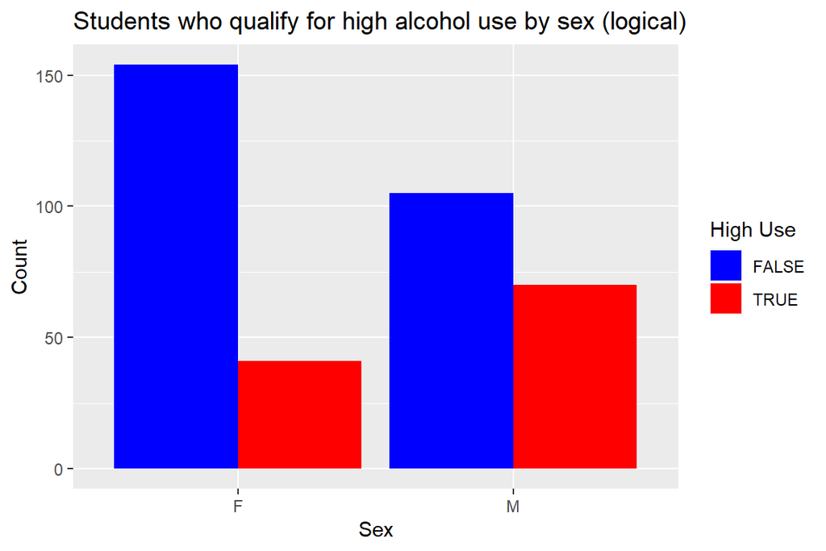

```
##
##   F   M
## 195 175
```

```
##
##  F  M
## 41 70
```

```
##
##     FALSE TRUE
##   F   154   41
##   M   105   70
```

We can see that out of female students, that frequent alcohol use is roughly twice as common among male students compared to females. Out of 195 female students, 41 qualify as gen-u-vine boozers whereas 70 out of male students make the cut. If we want a worse way of displaying the results, we can also use cross tabulation as on the last console printout.